# Airline Delays Analysis: Alaska vs AM West

Randy Howk

2025-09-28

# Airline Delays Analysis: Alaska vs AM West

## Introduction

This analysis examines arrival delay data for two airlines (Alaska and AM West) across five destinations: Los Angeles, Phoenix, San Diego, San Francisco, and Seattle. The data comes from “Numbersense” by Kaiser Fung (McGraw Hill, 2013).

Our goal is to compare the performance of these two airlines by analyzing their on-time and delayed flight statistics.

## Data Preparation

### Loading required libraries

```r
library(tidyr)
library(dplyr)
library(ggplot2)
library(knitr)
library(DT)
library(scales)
library(kableExtra) # used for nicer kable output
```

### Creating the dataset

First, create the dataset in a wide format (as in the original source), then tidy it for analysis.

```r
# Create the raw data in wide format
airline_data_wide <- data.frame(
  airline = c("ALASKA", "ALASKA", "AM WEST", "AM WEST"),
  status = c("on time", "delayed", "on time", "delayed"),
  los_angeles = c(497, 62, 694, 117),
  phoenix = c(221, 12, 4840, 415),
  san_diego = c(212, 20, 383, 65),
  san_francisco = c(503, 102, 320, 129),
  seattle = c(1841, 305, 201, 61)
)

# Show the wide-format table
kable(airline_data_wide,
      caption = "Original Airline Delay Data (Wide Format)",
      col.names = c("Airline", "Status", "Los Angeles", "Phoenix",
                    "San Diego", "San Francisco", "Seattle"))
```

Original Airline Delay Data (Wide Format)

| Airline | Status | Los Angeles | Phoenix | San Diego | San Francisco | Seattle |
| --- | --- | --- | --- | --- | --- | --- |
| ALASKA | on time | 497 | 221 | 212 | 503 | 1841 |
| ALASKA | delayed | 62 | 12 | 20 | 102 | 305 |
| AM WEST | on time | 694 | 4840 | 383 | 320 | 201 |
| AM WEST | delayed | 117 | 415 | 65 | 129 | 61 |

You can save the wide dataset to CSV for reuse.

```r
# write.csv(airline_data_wide, "airline_delays_wide.csv", row.names = FALSE)
```

## Data tidying and transformation

### Convert to long (tidy) format

```r
airline_data_long <- airline_data_wide %>%
  pivot_longer(
    cols = c(los_angeles, phoenix, san_diego, san_francisco, seattle),
    names_to = "destination",
    values_to = "flights"
  ) %>%
  mutate(
    destination = case_when(
      destination == "los_angeles" ~ "Los Angeles",
      destination == "phoenix" ~ "Phoenix",
      destination == "san_diego" ~ "San Diego",
      destination == "san_francisco" ~ "San Francisco",
      destination == "seattle" ~ "Seattle",
      TRUE ~ destination
    )
  )

kable(head(airline_data_long, 10), caption = "Airline Data in Long Format (First 10 rows)")
```

Airline Data in Long Format (First 10 rows)

| airline | status | destination | flights |
| --- | --- | --- | --- |
| ALASKA | on time | Los Angeles | 497 |
| ALASKA | on time | Phoenix | 221 |
| ALASKA | on time | San Diego | 212 |
| ALASKA | on time | San Francisco | 503 |
| ALASKA | on time | Seattle | 1841 |
| ALASKA | delayed | Los Angeles | 62 |
| ALASKA | delayed | Phoenix | 12 |
| ALASKA | delayed | San Diego | 20 |
| ALASKA | delayed | San Francisco | 102 |
| ALASKA | delayed | Seattle | 305 |

### Create analysis-ready dataset

```r
airline_analysis <- airline_data_long %>%
  pivot_wider(
    names_from = status,
    values_from = flights,
    names_repair = "minimal"
  ) %>%
  rename(
    on_time = `on time`,
    delayed = delayed
  ) %>%
  mutate(
    total_flights = on_time + delayed,
    delay_rate = delayed / total_flights,
    on_time_rate = on_time / total_flights
  )

DT::datatable(airline_analysis,
          caption = "Analysis-Ready Dataset",
          options = list(pageLength = 10, scrollX = TRUE)) %>%
  formatPercentage(c("delay_rate", "on_time_rate"), 2) %>%
  formatRound(c("on_time", "delayed", "total_flights"), 0)
```

|  | airline | destination | on_time | delayed | total_flights | delay_rate | on_time_rate |
| --- | --- | --- | --- | --- | --- | --- | --- |
| 1 | ALASKA | Los Angeles | 497 | 62 | 559 | 0.110912343470483 | 0.889087656529517 |
| 2 | ALASKA | Phoenix | 221 | 12 | 233 | 0.05150214592274678 | 0.9484978540772532 |
| 3 | ALASKA | San Diego | 212 | 20 | 232 | 0.08620689655172414 | 0.9137931034482759 |
| 4 | ALASKA | San Francisco | 503 | 102 | 605 | 0.168595041322314 | 0.8314049586776859 |
| 5 | ALASKA | Seattle | 1841 | 305 | 2146 | 0.1421248835041939 | 0.8578751164958062 |
| 6 | AM WEST | Los Angeles | 694 | 117 | 811 | 0.1442663378545006 | 0.8557336621454994 |
| 7 | AM WEST | Phoenix | 4840 | 415 | 5255 | 0.07897240723120837 | 0.9210275927687916 |
| 8 | AM WEST | San Diego | 383 | 65 | 448 | 0.1450892857142857 | 0.8549107142857143 |
| 9 | AM WEST | San Francisco | 320 | 129 | 449 | 0.2873051224944321 | 0.7126948775055679 |
| 10 | AM WEST | Seattle | 201 | 61 | 262 | 0.232824427480916 | 0.767175572519084 |

## Exploratory data analysis

### Summary statistics

```r
# Overall performance by airline
airline_summary <- airline_analysis %>%
  group_by(airline) %>%
  summarise(
    total_on_time = sum(on_time),
    total_delayed = sum(delayed),
    total_flights = sum(total_flights),
    overall_delay_rate = sum(delayed) / sum(total_flights),
    avg_delay_rate_by_route = mean(delay_rate),
    .groups = 'drop'
  )

kable(airline_summary,
      caption = "Overall Airline Performance Summary",
      col.names = c("Airline", "On Time", "Delayed", "Total Flights",
                    "Overall Delay Rate", "Avg Delay Rate by Route"),
      digits = 4) %>%
  kable_styling(full_width = FALSE)
```

Overall Airline Performance Summary

| Airline | On Time | Delayed | Total Flights | Overall Delay Rate | Avg Delay Rate by Route |
| --- | --- | --- | --- | --- | --- |
| ALASKA | 3274 | 501 | 3775 | 0.1327 | 0.1119 |
| AM WEST | 6438 | 787 | 7225 | 0.1089 | 0.1777 |

```r
# Performance by destination
destination_summary <- airline_analysis %>%
  group_by(destination) %>%
  summarise(
    total_on_time = sum(on_time),
    total_delayed = sum(delayed),
    total_flights = sum(total_flights),
    overall_delay_rate = sum(delayed) / sum(total_flights),
    .groups = 'drop'
  ) %>%
  arrange(desc(overall_delay_rate))

kable(destination_summary,
      caption = "Performance by Destination (Worst to Best)",
      col.names = c("Destination", "On Time", "Delayed", "Total Flights", "Delay Rate"),
      digits = 4) %>%
  kable_styling(full_width = FALSE)
```

Performance by Destination (Worst to Best)

| Destination | On Time | Delayed | Total Flights | Delay Rate |
| --- | --- | --- | --- | --- |
| San Francisco | 823 | 231 | 1054 | 0.2192 |
| Seattle | 2042 | 366 | 2408 | 0.1520 |
| Los Angeles | 1191 | 179 | 1370 | 0.1307 |
| San Diego | 595 | 85 | 680 | 0.1250 |
| Phoenix | 5061 | 427 | 5488 | 0.0778 |

### Visualizations

#### Delay rates by airline and destination

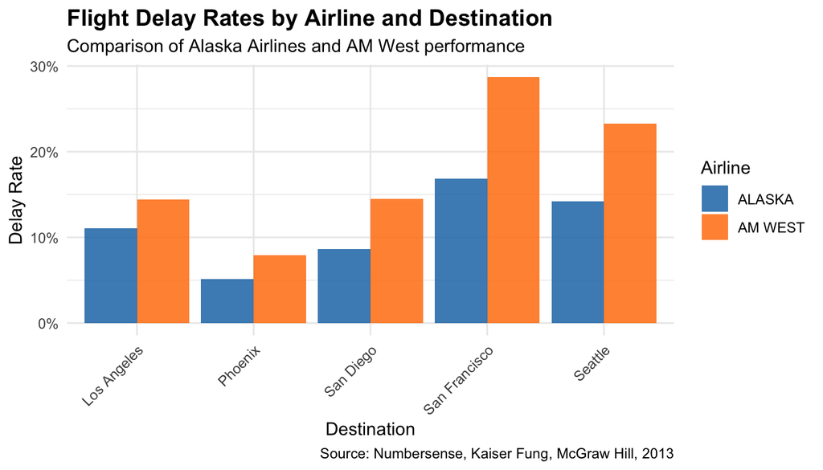

```r
ggplot(airline_analysis, aes(x = destination, y = delay_rate, fill = airline)) +
  geom_col(position = "dodge", alpha = 0.85) +
  scale_y_continuous(labels = percent_format()) +
  scale_fill_manual(values = c("ALASKA" = "#1f77b4", "AM WEST" = "#ff7f0e")) +
  labs(
    title = "Flight Delay Rates by Airline and Destination",
    subtitle = "Comparison of Alaska Airlines and AM West performance",
    x = "Destination",
    y = "Delay Rate",
    fill = "Airline",
    caption = "Source: Numbersense, Kaiser Fung, McGraw Hill, 2013"
  ) +
  theme_minimal() +
  theme(
    axis.text.x = element_text(angle = 45, hjust = 1),
    plot.title = element_text(size = 14, face = "bold")
  )
```

#### Flight volume comparison

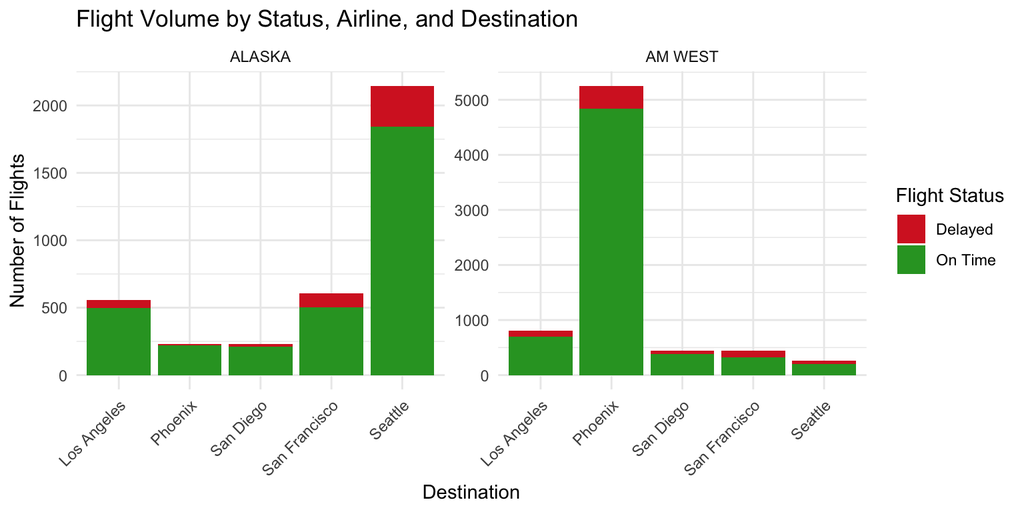

```r
airline_analysis %>%
  select(airline, destination, on_time, delayed) %>%
  pivot_longer(cols = c(on_time, delayed), names_to = "status", values_to = "flights") %>%
  ggplot(aes(x = destination, y = flights, fill = status)) +
  geom_col() +
  facet_wrap(~airline, scales = "free_y") +
  scale_fill_manual(
    values = c("on_time" = "#2ca02c", "delayed" = "#d62728"),
    labels = c("delayed" = "Delayed", "on_time" = "On Time")
  ) +
  labs(
    title = "Flight Volume by Status, Airline, and Destination",
    x = "Destination",
    y = "Number of Flights",
    fill = "Flight Status"
  ) +
  theme_minimal() +
  theme(axis.text.x = element_text(angle = 45, hjust = 1))
```